# Performance Evaluation of Classifications

Dario Strbenac

29 June 2018

# 1 Activity Overview

- Feature selection stability.
- Evaluation of overall error, sample-specific error, precision, recall.
- Comparison of various classifiers.

# 2 Feature Selection Stability

- If the genes being selected are the same ones in most of the cross-validations, then the classifier has good stability.
- `selectionPlot` provides a way to compare all pairs of gene selections within a classifier or between classifiers.
- Input is a list of `ClassifyResult` objects.
- For 20 permutations and 5 folds, there are $^{100}C_2 = 4950$ overlaps to compute. Like `runTests`, `selectionPlot` may utilise multiple processors.

Plot the distribution of overlaps of selected features of the DM and DD classifiers.

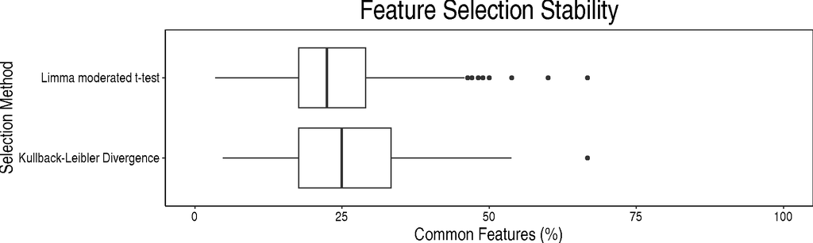

```r
withinChoices <- selectionPlot(list(classifiedDM, classifiedDD),
                               xVariable = "selectionName", xLabel = "Selection Method",
                               columnVariable = "None",
                               boxFillColouring = "None", boxLineColouring = "None",
                               rotate90 = TRUE)
```

## 2.1 Changing Elements of Saved Plots

- Almost all plots produced by ClassifyR are `ggplot` objects created by ggplot2.
- Such objects can be customised after creation because ggplot2 uses a ‘painting-over’ graphics model, unlike base R graphics.

Change the plot title to “Chosen Genes Overlaps”.  
**Hint**: Use the `ggtitle` function from ggplot2.

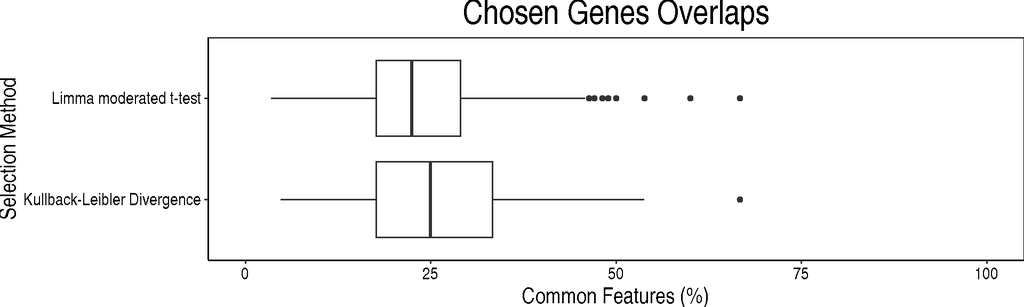

```r
library(ggplot2)
withinChoices + ggtitle("Chosen Genes Overlaps")
```

# 3 Feature Selection Commonality

- The features being selected by different classifications can be compared.
- Again, `selectionPlot` is used.

Compare the overlaps in features selected between DM and DD classifiers.  
**Hint**: The `comparison` parameter of `selectionPlot` controls what kind of comparison is made.

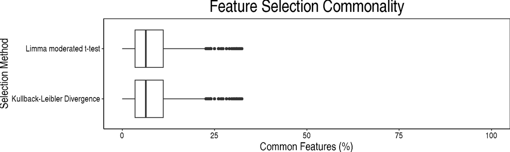

```r
betweenChoices <- selectionPlot(list(classifiedDM, classifiedDD),
                                comparison = "selectionName",
                                xVariable = "selectionName", xLabel = "Selection Method",
                                columnVariable = "None",
                                boxFillColouring = "None", boxLineColouring = "None",
                                rotate90 = TRUE)
```

Note that the sets of features chosen by the DM and DD classifiers have little in common.

# 4 Error / Accuracy of Predictions

- `calcCVperformance` calculates performance metrics for `ClassifyResult` objects. 12 different metrics can be calculated.
- Metrics are all applicable to data sets with two *or more* classes.
- `calcExternalPerformance` can be used on a pair of factor vectors of the same length. For example,

```r
actualClasses <- factor(c("Yes", "Yes", "No", "No", "No"))
predictedClasses <- factor(c("Yes", "No", "No", "No", "No"))
calcExternalPerformance(actualClasses, predictedClasses, "error")
```

```
## [1] 0.2
```

```r
calcExternalPerformance(actualClasses, predictedClasses, "accuracy")
```

```
## [1] 0.8
```

## 4.1 Balanced Error Rate for Resistance Classification

- Class sizes of resistance data set are imbalanced. Errors should be summarised by the balanced error rate.

For each of the three classifications done earlier, calculate the balanced error rate using `calcCVperformance`.  
**Hint**: The value of the parameter named `performanceType` needs to be changed from its default, which is the ordinary error rate.

```r
classifiedDM <- calcCVperformance(classifiedDM, "balanced error")
classifiedDD <- calcCVperformance(classifiedDD, "balanced error")
classifiedClinical <- calcCVperformance(classifiedClinical, "balanced error")

classifiedDM # Note that Performance Measures is no longer empty.
```

```
## An object of class 'ClassifyResult'.
## Data Set Name: AML.
## Classification Name: Changes in Means.
## Feature Selection Name: Limma moderated t-test.
## Features: List of length 20 of lists of length 5 of feature identifiers.
## Validation: 20 Permutations, 5 Folds.
## Predictions: List of data frames of length 20.
## Performance Measures: Balanced Error Rate.
```

## 4.2 Distribution of Balanced Error Rate

`performancePlot` can be used to plot the distribution of a metric to see its stability. The set of samples was predicted 20 times by each classifier.

Compare the distributions of balanced error rates of the three classifiers.  
**Hint**: The value of the `performanceName` parameter needs to be changed to specify the balanced error rate.

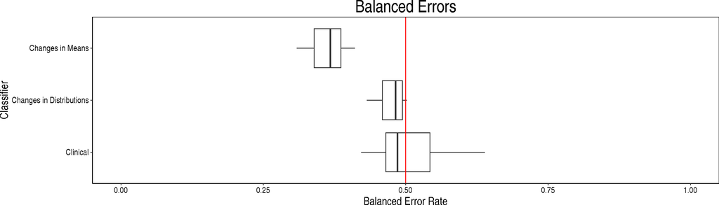

```r
errorPlot <- performancePlot(list(classifiedDM, classifiedDD, classifiedClinical),
                             performanceName = "Balanced Error Rate",
                             boxFillColouring = "None", boxLineColouring = "None",
                             columnVariable = "None", title = "Balanced Errors",
                             xLabel = "Classifier", rotate90 = TRUE, plot = FALSE)
library(ggplot2)
errorPlot + geom_hline(yintercept = 0.5, colour = "red")
```

Note that DM classification is the only classifier which does substantially better than random.

## 4.3 Sample-specific Error Rate

Calculate the sample-specific error rates for each patient.  
**Hint**: Use again the function named `calcCVperformance`.

```r
classifiedDM <- calcCVperformance(classifiedDM, "sample error")
classifiedDD <- calcCVperformance(classifiedDD, "sample error")
classifiedClinical <- calcCVperformance(classifiedClinical, "sample error")
classifiedClinical
```

```
## An object of class 'ClassifyResult'.
## Data Set Name: AML.
## Classification Name: Clinical.
## Feature Selection Name: Unspecified.
## Features: All used.
## Validation: 20 Permutations, 5 Folds.
## Predictions: List of data frames of length 20.
## Performance Measures: Balanced Error Rate, Sample-wise Error Rate.
```

Plot a heatmap of sample-wise errors using `samplesMetricMap`.  
**Hint**: Change the value of `showXtickLabels` to remove the sample labels from the x-axis.

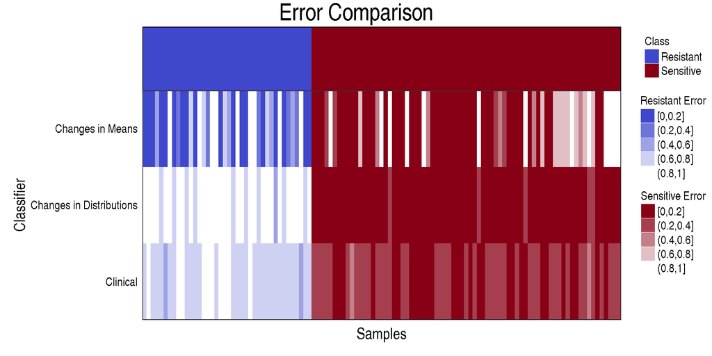

```r
errorPlot <- samplesMetricMap(list(classifiedDM, classifiedDD, classifiedClinical),
                              xAxisLabel = "Samples", yAxisLabel = "Classifier",
                              showXtickLabels = FALSE)
```

DLDA is the only method which has a similar error profile in the minority and majority class.

# 5 Precision, Recall, F1 Score

- Micro and macro versions of these metrics can be similarly calculated to the error rates demonstrated previously.
- Use the macro version because each class makes an equal contribution to the metric, unlike for the micro version.

Calculate the macro precision for the DM classifier using `calcCVperformance`.

```r
classifiedDM <- calcCVperformance(classifiedDM, "macro precision")
performance(classifiedDM)[["Macro Precision"]]
```

```
##  [1] 0.6298246 0.6048021 0.6174338 0.6708701 0.5907051 0.5907051 0.6062619
##  [8] 0.5818096 0.6488889 0.6231343 0.6705351 0.6490196 0.6567852 0.6269231
## [15] 0.6523211 0.6241303 0.5930818 0.6158930 0.6419987 0.6752982
```